# Assignment 4 Stat 506 Spring 2015

Due February 13-14, 2015  
Turn in to Dropbox on D2L.

Use data on football players salaries [found here.](http://www.math.montana.edu/~jimrc/classes/stat506/data/2014-NFL-Shared-Census.xls)  
I downloaded it from a blog at [besttickets.com](http://www.besttickets.com/blog/nfl-player-census-2014/)  
*Note: this is in a MS Excel spreadsheet format. You’ll have to convert it to be read into R and SAS.*

Positions are Center, CornerBack, Defensive End, Defensive Tackle, Guard, Kicker, Linebacker, Long Snapper, Nose Tackle, Punter, Quarterback, Running Back, Safety, Offensive Tackle, Tight End, and Wide Receiver.

Our goal is to look for relationships between the variables we have available to see if we can build a model which explains why some players get paid much more than others. I am assuming that most of us are not very knowledgeable about players’ salaries, so that ‘black box’ methods are reasonable.  
*Reading in the data: 2 pts*

1. I’m sure you know that salaries often exhibit a skewed distribution.
1. Investigate these data to see if a transformation is needed. If so, do it throughout this assignment. (Explain.) *1 pt*

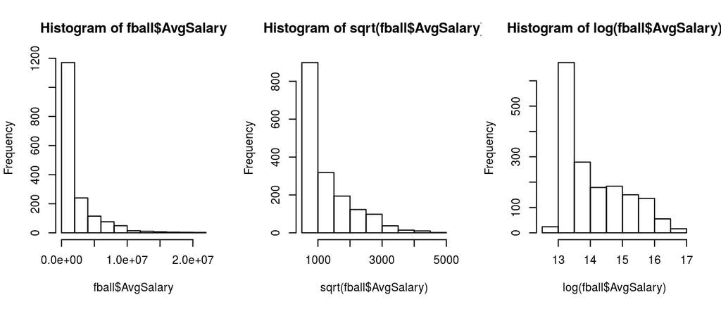

*I am using log(salary) because it has a more symmetric distribution. WE will always have a lump of rookies at the bottom end of the scale getting the minimum salary, so no transformation fixes that. I removed these variables: number, first name, last name, college, birth city, high school, and high school city because I think they are non-informative. I plotted boxplots of birth-state and high school-state, but could see no pattern. They soak up many degrees of freedom, and think they should not be important. I left them in, but will be surprised if they get used.*  
*I filled two NA’s for Nteams with 1’s, as those players had 3 and 4 years of experience.*

2. Decide which variables you will consider as predictors. Format them in a way that makes sense. (Which are factors?) Provide initial plots to see how they might relate to salary. *(4 pts)*

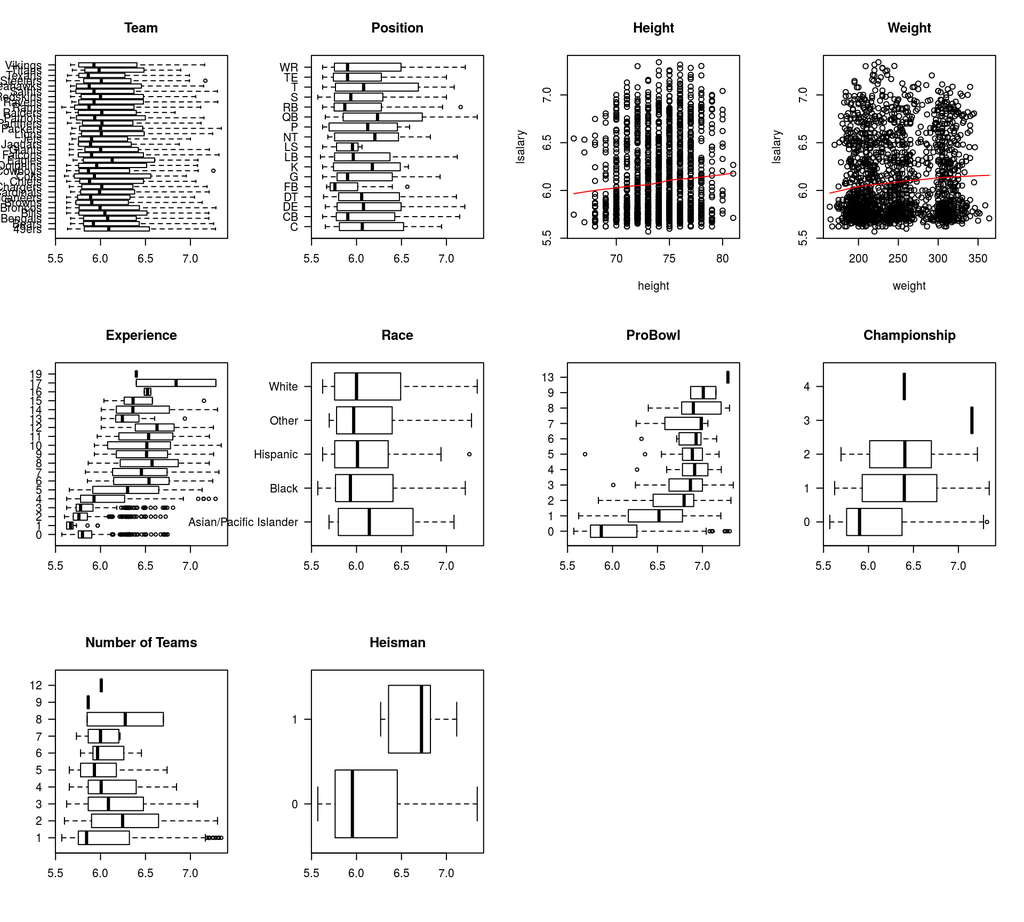

*I didn’t realize which positions tend to get more money. I wonder if there is a weight by position interaction because for some positions weight is an asset, for others a detriment.*

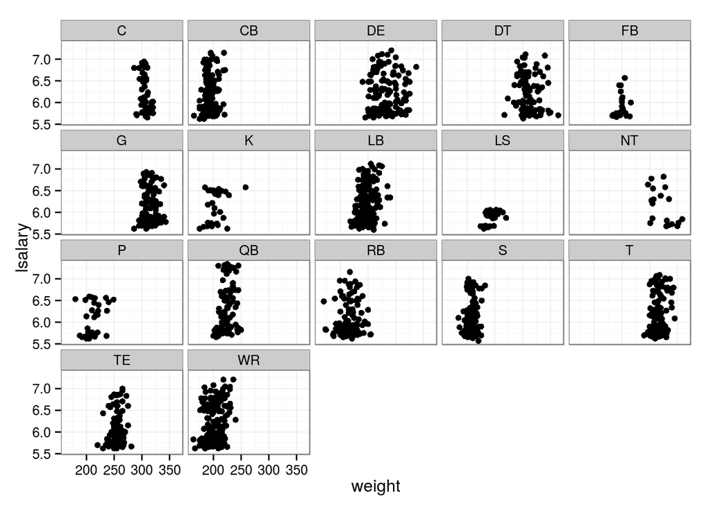

2. Demonstrate how the step function can be used in R to do forward, backward, or ‘stepwise’ variable selection. Start with a full model to use “backward” and for one “both directions” fit. Start with just one variable to use “forward” and another “both” fit. Do the four results agree? What is the best AICc fit you’ve found? *(2 pts)*

3. Read the data into SAS. Use the PROC GLMSELECT (2006?) to fit a variety of models. Refer to the example on modeling baseball salaries based on performance measures. Use forward, backward and stepwise. For at least one of these invoke “stats = all” and compare the different criterion’s favorite models. *(2 pts)*

4. Using a favorite model from #3, fit in PROC MIXED with a random team intercept. Does this explain much more variance? Do effects look stronger as a result? *( 2 pts)*

*I’m still trying to figure out what GLMSELECT does. I fit the model in PROC GLM using predictors `exp nteams weight position` and `weight * position`. All Type I SSQ p-values returned are less than 0.01 (and even Type III’s are the same except weight goes up to 0.045) so I don’t see why GLMSELECT does not include these terms. I fit this model in PROC MIXED and coefficient estimates remained the same, and the team-to-team variance estimate came back as a zero, so this is not any different from the estimates above. The first of these are compared below*

SAS Solutions

| Term | GLM Estimate | Mixed Estimate |
| --- | --- | --- |
| Intercept | 5.10 (0.379) | 5.10 (0.379) |
| EXP | 0.0903 (0.003) | 0.0903 (0.003) |
| Nteams | -0.086 (0.008) | -0.086 (0.008) |
| position C | 5.25 (2.12) | 5.25 (2.12) |
| weight | 0.0039 (0.0019) | 0.0039 (0.0019) |
| weight by position C | -0.0185 (0.007) | -0.0185 (0.007) |

5. Repeat #4 in R using a favorite model from #2. Explain how much difference you see between teams. *(2 pts)*

[output not shown]

## R Code

```r
setwd("/home/jimrc/classes/stat506/homework/assn4/")
fball <- read.csv("../../data/2014-NFL-Census-Shared.csv", sep = "\t", as.is=TRUE)
names(fball)
summary(fball)
fball$Nteams[c(286,336)-2] <- 1
fball <- subset(fball, AvgSalary > 1)
par(mfrow=c(1,3))
hist(fball$AvgSalary)
hist(sqrt(fball$AvgSalary))
hist(log(fball$AvgSalary))

fball$BDAY <- lubridate::ymd(fball$BDAY)
fball$POS <- factor(fball$POS)
fball$X <- NULL
fball$Race <- factor(fball$Race)
names(fball)[1] <- "team"
names(fball)[5] <- "position"
names(fball)[6:7] <- c("height","weight")
fball$team <- factor(fball$team)
fball$BirthState <- factor(fball$BirthState)
fball$HSState <- factor(fball$HSState)
fball <- fball[, -c(2:4,8,10,12,15,16)]
fball$lsalary <- log10(fball$AvgSalary +1)
fball$Champ <- ifelse(fball$Champ=="NO",0,as.numeric(fball$Champ))
fball$Heisman  <- ifelse(fball$Heisman =="NO",0,1)
fball$AvgSalary <- NULL
```

```r
par(mfrow=c(3,4))
boxplot(lsalary ~ team, fball, horizontal = TRUE, las = 1,main = "Team")
boxplot(lsalary ~ position, fball, horizontal = TRUE, las = 1, main = "Position")
plot(lsalary ~ height, fball, main = "Height")
 lines(lowess(fball$height, fball$lsalary), col = 2)
plot(lsalary ~ weight, fball, main = "Weight")
 lines(lowess(fball$weight, fball$lsalary), col = 2)
boxplot(lsalary ~ EXP, fball, horizontal = TRUE, las = 1, main = "Experience")
boxplot(lsalary ~ Race, fball, horizontal = TRUE, las = 1, main = "Race")
##boxplot(lsalary ~ BirthState, fball, horizontal = TRUE, las = 1)
##boxplot(lsalary ~ HSState, fball, horizontal = TRUE, las = 1)
boxplot(lsalary ~ ProBowler, fball, horizontal = TRUE, las = 1, main = "ProBowl")
boxplot(lsalary ~ Champ, fball, horizontal = TRUE, las = 1, main = "Championship")
boxplot(lsalary ~ Nteams, fball, horizontal = TRUE, las = 1, main = "Number of Teams")
boxplot(lsalary ~ Heisman, fball, horizontal = TRUE, las = 1, main = "Heisman")
table(fball$Heisman)
 ## write.csv(fball, file="football.csv", row.names=FALSE, quote=FALSE)
 ## I don't like Heisman (too few). Nteams is too like experience r = .4
```

```r
require(ggplot2, quietly=TRUE)
qplot( x=weight,y=lsalary,data=fball)  + facet_wrap(~position) + theme_bw() ##+ geom_smooth()
```

```r
fitAll <- lm(lsalary ~ . + position *weight, data = fball[,-1], subset = complete.cases(fball))
anova(fitAll)
# drop1(fitAll)
backstepFit <- step(fitAll,trace=FALSE)
rownames(anova(backstepFit))
fwdstepFit <- step( lm(lsalary ~ position, fball, subset = complete.cases(fball)), scope=list(upper=formula(fitAll)),dir="for", trace=FALSE)
rownames(anova(fwdstepFit))
stepUpstepFit  <- step( lm(lsalary ~ position, fball, subset = complete.cases(fball)), scope=list( lower = ~1, upper=formula(fitAll)),dir="both", trace = FALSE)
rownames(anova(stepUpstepFit))
stepDwnstepFit  <- step( fitAll, scope=list( lower = ~1, upper=formula(fitAll)),dir="both", trace = FALSE)
rownames(anova(stepDwnstepFit))
```

```r
require(lme4, quietly=TRUE)
mixedFit <- lmer(lsalary ~ position + height +weight + EXP + ProBowler+Nteams + Heisman +(1|team), data = subset(fball, complete.cases(fball)))
anova(mixedFit,test="Chisq")
confint(mixedFit, parm = 1:2)
```

```r
out1 <- round(summary(backstepFit)$coef[17:22, 1:2],3)
out2 <- round(summary(mixedFit)$coefficients[17:22, 1:2],3)
output <- matrix(c(rownames(out1), paste(out1[,1]," (",out1[,2],")",sep=""),
                  paste(out1[,1]," (",out1[,2],")",sep="")), ncol=3,
                  dimnames = list(NULL, c("Effect", "lm-Estimates", "lmer-Estimates")))
knitr::kable(output)
```

## SAS Code – printed through R

```r
  ## with code chunk option:  comment=""
temp <- scan(file="football.sas", what = "a", sep = "\n")
cat(paste(temp,"\n"))
```

```
Proc import  datafile="/folders/myfolders/football.csv"
     out=fball   dbms=dlm    replace;
     delimiter=",";
     getnames=YES;
     run;

  *PROC CONTENTS data = fball;
  *RUN;

  title "Forward stepwise";
  PROC GLMSELECT data = fball plot = criterionPanel ;
    class position team birthstate hsstate race;
    model lsalary = weight position weight*position  race exp nteams height birthstate hsstate/
                    stats=all orderselect selection = forward stop = adjrsq hier=single;
                    run;

  title "Backward Stepwise";
  PROC GLMSELECT data = fball plot = criterionPanel ;
    class position team birthstate hsstate race;
    model lsalary = weight position weight*position  race exp nteams height birthstate hsstate /
                    stats=all orderselect selection = backward  hier=single
                    slstay = .05;
  run;

  title "Stepwise Stepwise";
  PROC GLMSELECT data = fball plot = criterionPanel ;
    class position team birthstate hsstate race;
    model lsalary = weight position height height*position race exp nteams birthstate hsstate /
                    stats=all orderselect selection = stepwise slentry=0.20
                    slstay = 0.1 stop = aicc hier = single;
  run;
```